# Courera. Peer Assessment 1 - Reproducible Research

Pavel Milovankin

**Loading and preprocessing the data:**

```r
setwd("D:/INFOR/Obuchalki/Data Science Specialization/011-Reproducible Research/Course Project 1")
activity <- read.csv("activity.csv", colClasses = c("integer", "Date", "factor"))
        activity$month <- as.numeric(format(activity$date, "%m"))
        noNA <- na.omit(activity)
        rownames(noNA) <- 1:nrow(noNA)
```

**What is mean total number of steps taken per day?**

1. Calculate the total number of steps taken per day

```r
totalSteps <- aggregate(noNA$steps, list(Date = noNA$date), FUN = "sum")$x
sum(totalSteps)
```

```
## [1] 570608
```

2. Make a histogram of the total number of steps taken each day

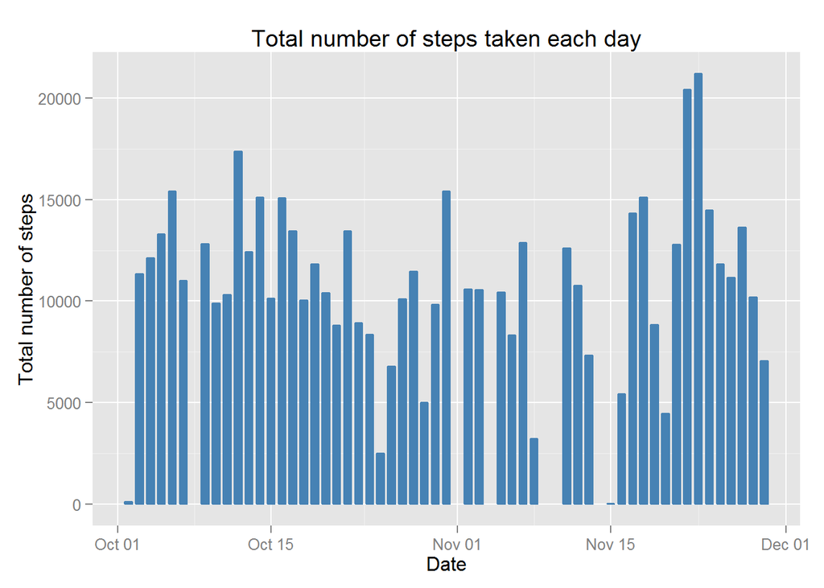

```r
library(ggplot2)
ggplot(noNA, aes(date, steps)) + geom_bar(stat = "identity", colour = "steelblue", fill = "steelblue", width = 0.7) + labs(title = "Total number of steps taken each day", x = "Date", y = "Total number of steps")
```

**What is the average daily activity pattern?**

1. Make a time series plot (i.e. type = “l”) of the 5-minute interval (x-axis) and the average number of steps taken, averaged across all days (y-axis)

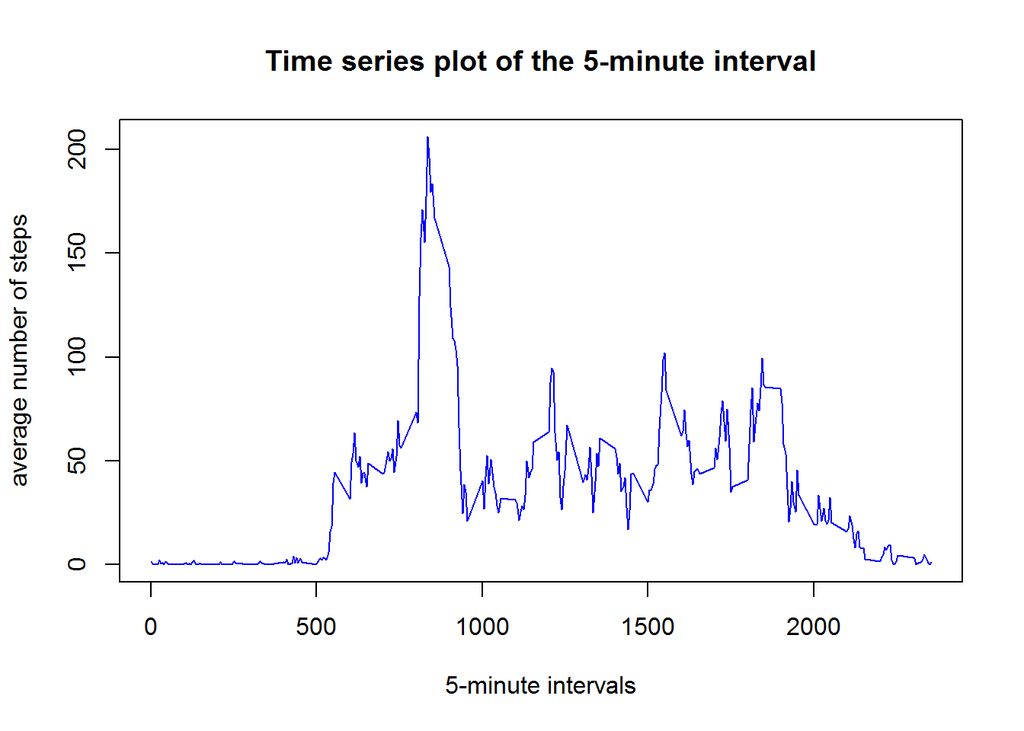

```r
avg.steps <- aggregate(noNA$steps, list(interval = as.numeric(as.character(noNA$interval))), FUN = "mean")
names(avg.steps)[2] <- "mean.of.steps"

plot(avg.steps, type = "l", col = "blue",
     main = "Time series plot of the 5-minute interval",
     xlab = "5-minute intervals", ylab = "average number of steps")
```

2. Which 5-minute interval, on average across all the days in the dataset, contains the maximum number of steps?

```r
avgSteps[avg.steps$mean.of.steps == max(avg.steps$mean.of.steps), ]$interval
```

[output not shown]

**Imputing missing values**

1. The total number of rows with NAs:

```r
sum(is.na(activity))
```

```
## [1] 2304
```

2. Devise a strategy for filling in all of the missing values in the dataset. The strategy does not need to be sophisticated. For example, you could use the mean/median for that day, or the mean for that 5-minute interval, etc.

My strategy is to use the mean for that 5-minute interval to fill each NA value in the steps column.